# Test STING IDM v0.5

Nick Isaac

16/02/2023

# Introduction

In this document, we’re exploring the properties of the model proposed for Minimum Viable Scheme for EU Pollinator Monitoring Scheme. In this iteration, there are two data types: pan traps and transect walks. Both data types are surveyed on the same day each year. There are `v` visits to `n` sites: both numbers can be modified. We first define the model, then simulate data using user-defined parameters. We then try to recover these parameters for one simulated dataset. There are shared between the data types for a covariate and for the detection phenology.

## Priorities for future development

In approximate order of priority: - Zero inflated Poisson - parameterize simulations using data from the pilot studies - missing visits - ignoring the phenology (even though it is important)

Second tier priority - model the data types separately - Multispecies - Multi-year - spatially-explicit - Multi-national - is the model equally applicable to central place foragers vs others?

# Setting up the model

Set some global parameters

```r
nSites <- 75
nVisits <- 4
maxDate <- 250 # latest survey date. 250 = mid Sept
minDate <- 100 # earliest survey date. 10 = mid April
sim.pars <- list(alpha.s = 0, # state intercept
              beta.s = 1, # state covariate
              cov = rnorm(n = nSites),
              alpha.p = 0, # logit probability of detection per pan trap (0 = 50%)
              beta1 = 200, # date when detectability is highest
              beta2 = 30, # standard deviation of detection phenology
              Multiplier = 50, # Multiplier for counts per unit intensity.
              phScale = 20) #
Dates <- round(array(runif(n = nSites*nVisits, min = minDate, max = maxDate),
              dim = c(nSites, nVisits)), 0)
```

Define the model code in Nimble

```r
obsMod <- TRUE
modelcode <- nimbleCode({
    ######################### state model
  for (i in 1:nsite) {
    linPred[i] <- alpha.s + beta.s * cov[i]
    log(lambda[i]) <- linPred[i]
    cloglog(psi[i]) <- linPred[i]
    z[i] ~ dbern(psi[i]) # True occupancy status
  }

  ######################### state model priors
  alpha.s ~ dnorm(0, 0.0001)
  beta.s ~ dnorm(0, 0.0001)

if(obsMod){ # for debugging
  ######################### Obs model
  for (i in 1:nsite) {
    for (j in 1:nvisit) {

      ##### pan traps
      y1[i,j] ~ dbin(size = nT[i,j], prob = Py[i,j]) # Observed data
      Py[i,j] <- z[i] * p1[i,j]
      logit(p1[i,j]) <- alpha.p + logit(pThin[i,j])

      ##### transects
      y2[i,j] ~ dpois(lambdaThin[i,j]) # Observed counts. Might need a NegBin here or Zero-inflated
      lambdaThin[i,j] <- Multiplier * lambda[i] * pThin[i,j]

      #### shared: phenology
      logit(pThin[i,j]) <- phScale * f_JD[JulDate[i,j]]
  }}
}
  ######################### Obs model priors
  phScale ~ T(dt(0, 1, 1), 0, Inf) # Half Cauchy
  alpha.p ~ dnorm(-2, 0.0001) # p1 is detection probability per pan trap at peak phenology; could replace with a logistic model
  Multiplier ~ T(dt(0, 1, 1), 0, Inf)

  ######################### Seasonality shared effect
  beta1 ~ dunif(100, 250) # peak detectability/activity. Constrained to fall within the field season
  beta2 ~ T(dt(0, 1, 1), 0, 500) # Half Cauchy. Stdev of phenology. At sd=500 the curve is entirely flat

  for (d in 1:365){
    f_JD[d] <- 1/((2*3.14159265359)^0.5 * beta2) * exp(-((d - (beta1))^2 / (2* beta2^2)))
    # could simplify this and evaluate only for dates in the dataset
  }

  #########################  derived parameters
  psi.fs <- mean(z[1:nsite])
  mu.lambda <- mean(lambda[1:nsite])
})
```

# Run Simulation

Next step is to simulate some data for that model

```r
# set the parameters for a simulation

mcSim <- nimbleModel(modelcode,
                     constants = list(nsite = nSites,
                                   nvisit = nVisits,
                                   alpha.s = sim.pars$alpha.s,
                                   beta.s = sim.pars$beta.s,
                                   cov = sim.pars$cov,
                                   phScale = sim.pars$phScale,
                                   alpha.p = sim.pars$alpha.p,
                                   Multiplier = sim.pars$Multiplier,
                                   beta1 = sim.pars$beta1,
                                   beta2 = sim.pars$beta2,
                                   nT = array(data = 5, dim = c(nSites, nVisits)),
                                   JulDate = Dates
                                )
                     #inits = as.list(sim.pars)
                     )
```

```
## Defining model
```

```
##   [Note] Using 'alpha.p,alpha.s,beta.s,beta1,beta2,Multiplier,phScale' (given within 'constants') as data.
```

```
## Building model
```

```
## Setting data and initial values
```

```
## Running calculate on model
##   [Note] Any error reports that follow may simply reflect missing values in model variables.
```

```
## Checking model sizes and dimensions
```

```
##   [Note] This model is not fully initialized. This is not an error.
##          To see which variables are not initialized, use model$initializeInfo().
##          For more information on model initialization, see help(modelInitialization).
```

```r
CmcSim <- compileNimble(mcSim) # note that we compile the operational model not the code!
```

```
## Compiling
##   [Note] This may take a minute.
##   [Note] Use 'showCompilerOutput = TRUE' to see C++ compilation details.
```

```r
nodesToSim <- CmcSim$getDependencies(c("psi", "lambda"),# "p1", "pThin"),
                                           self = F, downstream = T)
#nodesToSim
CmcSim$simulate(nodesToSim)
#CmcSim$simulate()
#head(CmcSim$y1)[, 1:2]
#head(CmcSim$y2)[, 1:2]
head(CmcSim$y1)
```

```
##      [,1] [,2] [,3] [,4]
## [1,]    3    3    1    3
## [2,]    3    3    3    1
## [3,]    2    2    2    4
## [4,]    3    2    3    4
## [5,]    3    5    1    2
## [6,]    0    0    0    0
```

```r
head(CmcSim$y2)
```

```
##      [,1] [,2] [,3] [,4]
## [1,]  103   90  131  134
## [2,]   13   21   34   11
## [3,]   40   28   25   32
## [4,]   57   55   58   67
## [5,]  111   90  114   96
## [6,]   12   16   19   25
```

```r
head(with(CmcSim, cbind(lambda, psi, z)))
```

```
##         lambda       psi z
## [1,] 4.2556255 0.9858158 1
## [2,] 0.8866180 0.5879530 1
## [3,] 1.4058455 0.7548403 1
## [4,] 2.2559785 0.8952290 1
## [5,] 3.7422769 0.9762999 1
## [6,] 0.6967515 0.5017989 0
```

To run the simulation I’ve fixed the values of everything in the simulation except `y1` and `y2`.

Summarise the simulated data

```r
occSites <- with(CmcSim, apply(cbind(y1), 1, max)>0)
(simSum  <- c(
  naiveOcc = mean(occSites),
  reportingRate = mean(with(CmcSim, y1/5)), # per pan trap
  meanCount = mean(CmcSim$y2),
  reportingRate_1 = mean(with(CmcSim, y1/5)[occSites,]), # per pan trap
  meanCount_1 = mean(CmcSim$y2[occSites,])
))
```

```
##        naiveOcc   reportingRate       meanCount reportingRate_1     meanCount_1
##       0.5866667       0.3060000      47.6166667       0.5215909      69.7102273
```

# Fit the model

Now fit the model on simulated data

```r
# step 1 create an operational from from NIMBLE/JAGS/BUGS code
model <- nimbleModel(code = modelcode,
                     constants = list(nsite = nSites,
                                      nvisit = nVisits,
                                      cov = sim.pars$cov,
                                      nT = array(data = 5, dim = c(nSites, nVisits)),
                                      JulDate = Dates
                     ),
                     data = list(y1 = CmcSim$y1, y2 = CmcSim$y2),
                     inits = list(z = apply(CmcSim$y1 > 0, 1, max),
                                  alpha.s = cloglog(simSum["naiveOcc"]),
                                  beta.s = rnorm(1, 0, 1),
                                  alpha.p = simSum["reportingRate_1"],
                                  beta1 = 180,
                                  beta2 = 50,
                                  Multiplier = 1,
                                  phScale = 1)
)
```

```
## Defining model
```

```
## Building model
```

```
## Setting data and initial values
```

```
## Running calculate on model
##   [Note] Any error reports that follow may simply reflect missing values in model variables.
```

```
## Checking model sizes and dimensions
```

```r
# step 2 build an MCMC object using buildMCMC(). we can add some customization here
occMCMC <- buildMCMC(model,
                     monitors = c("mu.lambda", #"psi.fs",
                                  'alpha.s', "beta.s",
                                  'alpha.p', "phScale","Multiplier",
                                  "beta1", "beta2"),
                     thin = 3,
                     useConjugacy = FALSE) # useConjugacy controls whether conjugate samplers are assigned when possible
```

```
## ===== Monitors =====
## thin = 3: alpha.p, alpha.s, beta.s, beta1, beta2, mu.lambda, Multiplier, phScale
## ===== Samplers =====
## RW sampler (7)
##   - alpha.s
##   - beta.s
##   - phScale
##   - alpha.p
##   - Multiplier
##   - beta1
##   - beta2
## binary sampler (75)
##   - z[]  (75 elements)
```

```r
#about 5 seconds

# step 3 before compiling the MCMC object we need to compile the model first
Cmodel <- compileNimble(model) # NJBI: I don't understand why this step is necessary
```

```
## Compiling
##   [Note] This may take a minute.
##   [Note] Use 'showCompilerOutput = TRUE' to see C++ compilation details.
```

```r
# 25 seconds (less for fewer nodes)

# now the MCMC (project = NIMBLE model already associated with a project)
CoccMCMC <- compileNimble(occMCMC, project = model)
```

```
## Compiling
##   [Note] This may take a minute.
##   [Note] Use 'showCompilerOutput = TRUE' to see C++ compilation details.
```

```r
# instantaneous

# and now we can use either $run or runMCMC() on the compiled model object.
system.time(
  runMCMC_samples <- runMCMC(CoccMCMC, nburnin = 25e3, niter = 3e4, nchains = 3, samplesAsCodaMCMC = T)
) # 17 seconds for 10K iterations with 3 visits/site
```

```
## Running chain 1 ...
```

```
## |-------------|-------------|-------------|-------------|
## |-------------------------------------------------------|
```

```
## Running chain 2 ...
```

```
## |-------------|-------------|-------------|-------------|
## |-------------------------------------------------------|
```

```
## Running chain 3 ...
```

```
## |-------------|-------------|-------------|-------------|
## |-------------------------------------------------------|
```

```
##    user  system elapsed
##   90.02    0.33   92.33
```

# Examine the model output

Plot the MCMC traces

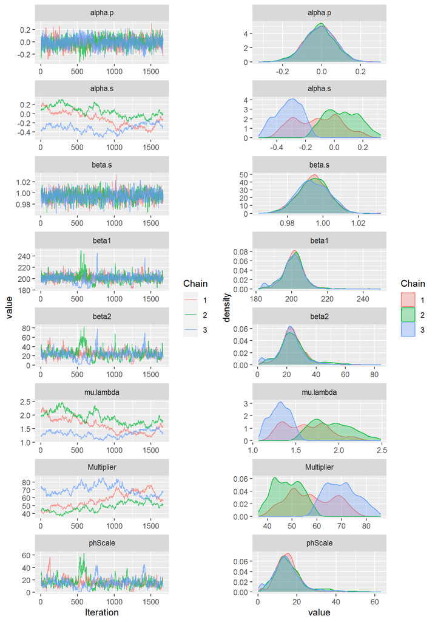

```r
plot1 <- runMCMC_samples %>% ggs() %>% ggs_traceplot(greek = TRUE)
plot2 <- runMCMC_samples %>% ggs() %>% ggs_density(greek = TRUE)
gridExtra::grid.arrange(plot1, plot2, ncol=2)
```

Have we recovered the simulated values?

```r
temp <- unlist(sim.pars[!names(sim.pars) %in% "cov"])
temp2 <- data.frame(name = names(temp), simulated = temp)

pars <- as.data.frame(summary(runMCMC_samples)$statistics)
pars$name <- rownames(pars)

#pars$simulated <- unlist(sim.pars[match(rownames(pars), names(sim.pars))])

pars <- merge(temp2, pars, all=TRUE)
print(pars)
```

```
##         name simulated         Mean           SD     Naive SE Time-series SE
## 1    alpha.p         0  -0.01052163  0.078789050 0.0011144683   0.0034924057
## 2    alpha.s         0  -0.12729324  0.196253841 0.0027760037   0.0399640520
## 3     beta.s         1   0.99455159  0.008733896 0.0001235406   0.0002553926
## 4      beta1       200 200.93578051  6.590275407 0.0932192143   0.3705621334
## 5      beta2        30  23.64773878  9.514861678 0.1345873845   0.8409578377
## 6  mu.lambda        NA   1.61360075  0.320827883 0.0045380991   0.0654492273
## 7 Multiplier        50  58.58462757 11.525642614 0.1630298102   2.3701220882
## 8    phScale        20  15.54762009  7.742211492 0.1095133098   0.7321545749
```

```r
#pars[,c(ncol(pars),1:(ncol(pars)-1))]
```

It would be quite useful to have the median here as well.

Now extract the Gelman-Rubin statistic (aka Rhat)

```r
# Rhat
gelman.diag(runMCMC_samples) # fails if psi.fs is included
```

```
## Potential scale reduction factors:
##
##            Point est. Upper C.I.
## Multiplier       2.40       4.73
## alpha.p          1.01       1.02
## alpha.s          2.65       4.87
## beta.s           1.00       1.01
## beta1            1.01       1.04
## beta2            1.01       1.04
## mu.lambda        2.76       4.92
## phScale          1.03       1.09
##
## Multivariate psrf
##
## 2.27
```

```r
# Autocorrelation plots
#autocorr.plot(runMCMC_samples)
```

Plot detection phenology

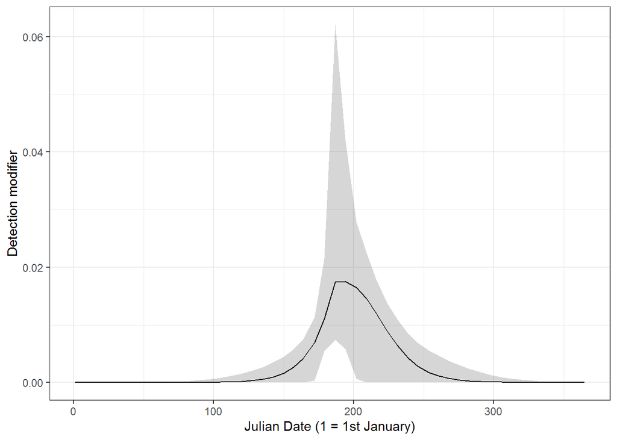

```r
beta1 <- melt(sapply(runMCMC_samples, function(x) x[,"beta1"]))$value
beta2 <- melt(sapply(runMCMC_samples, function(x) x[,"beta2"]))$value
jul_dates <- round(seq(from = 1, to = 365, length.out = 50),0)
pDet <- melt(sapply(jul_dates, function(jd){
  (1/((2*pi)^0.5 * beta2) * exp(-((jd - beta1)^2 / (2* beta2^2))))
}))

pDetSumm <- pDet %>%
  group_by(Var2) %>%
  summarise(mean = mean(value),
            lowerCI = quantile(value, 0.025),
            upperCI = quantile(value, 0.975)
  ) %>%
  ungroup()
pDetSumm$JulDate <- jul_dates[pDetSumm$Var2]
(detPlot <- ggplot(data = pDetSumm, (aes(x=JulDate))) +
    geom_line(aes(y=mean)) +
    geom_ribbon(aes(ymin=lowerCI, ymax=upperCI), alpha=0.2) +
    theme_bw() +
    xlab("Julian Date (1 = 1st January)") +
    ylab("Detection modifier"))
```